# NYC Schools Perceptions

Dennis Jonathan

5/11/2021

For this exercise, we will try and apply what we have learned before regarding techniques to clean and analyze a fairly large real-world dataset: Data on parent, student, and teacher perceptions of New York City schools collected using [surveys](https://data.cityofnewyork.us/Education/2011-NYC-School-Survey/mnz3-dyi8). The general theme of the data we will be working with are responses to surveys designed to gauge parent, student, and teacher perceptions of the quality of New York City schools. In this guided project, we’ll try investigating the following questions:

- Do student, teacher, and parent perceptions of NYC school quality appear to be related to demographic and academic success metrics?
- Do students, teachers, and parents have similar perceptions of NYC school quality?

We will use the surveys above along with a [combined data](https://data.world/dataquest/nyc-schools-data/workspace/file?filename=combined.csv) called `combined.csv` which consists of several test scores and other information regarding schools in New York which we have worked on previously.

The exercise will primarily focus on high schools (`combined.csv` contains data only from high schools) with the surveys as additional resources.

## Prerequisites

```r
# Shutting off warning messages
options(warn=-1)

# Importing tidyverse
library(tidyverse)
```

## Importing the Data

We will now import three datasets which will be used for the analysis. As for the surveys, we will utilized the `.tsv` version instead of the `.xlsx`, to import it in, we will be using the function `read_tsv()`.

```r
combined <- read_csv("combined.csv")
survey <- read_tsv("masterfile11_gened_final.txt")
survey_d75 <- read_tsv("masterfile11_d75_final.txt")
```

Now that we have imported the data in, we can begin.

## Data Cleaning

The first issue that rises is that the survey might contain every type of schools which will be quite redundant further on since we will be limiting our scope to only high schools (which we will get from the `survey` dataframe) and every district 75 schools (which we will get from `survey_d75`). We will also only use variables that contain aggregate scores (columns ending with `_11`) and also DBN (in order to join this data to `combined`).

```r
# Selecting only the required data from survey
survey <- survey %>%
  filter(schooltype == "High School") %>%
  select(dbn,schoolname,schooltype,saf_p_11:aca_tot_11)

# Selecting the required data from survey_d75
survey_d75 <- survey_d75 %>%
  select(dbn,schoolname,schooltype,saf_p_11:aca_tot_11)

# Combining both dataset together
survey_com <- survey %>% bind_rows(survey_d75)

# Renaming the DBN column so that it is the same with combined
survey_com <- survey_com %>% rename(DBN = dbn)
```

After getting the data that we needed, there was a possibility that we could combine both dataframe into one. To do this, we used `bind_rows()` to combine both data set since we had selected the same columns for both occasion. Next we will join our new data to `combined` by using `left_join()`.

```r
combined_survey <- combined %>%
  left_join(survey_com, by = "DBN")
```

## Analysis

### 1. Correlations

Now we will find whether there is any interesting relationships between SAT scores and the survey answers. To do this, we will create a correlation matrix using the function `cor()`.

```r
# Creating a correlation matrix
cor_mat <- combined_survey %>%
  select(avg_sat_score, saf_p_11:aca_tot_11) %>%
  cor(use = "pairwise.complete.obs") %>%
  as_tibble(rownames = "variable")

# Printing the correlation matrix
print(cor_mat %>% select(variable, avg_sat_score))
```

```
## # A tibble: 17 x 2
##    variable      avg_sat_score
##    <chr>                 <dbl>
##  1 avg_sat_score       1
##  2 saf_p_11            0.0891
##  3 com_p_11           -0.114
##  4 eng_p_11            0.00943
##  5 aca_p_11            0.00828
##  6 saf_t_11            0.309
##  7 com_t_11            0.107
##  8 eng_t_11            0.0561
##  9 aca_t_11            0.141
## 10 saf_s_11            0.277
## 11 com_s_11            0.162
## 12 eng_s_11            0.170
## 13 aca_s_11            0.293
## 14 saf_tot_11          0.276
## 15 com_tot_11          0.0891
## 16 eng_tot_11          0.0948
## 17 aca_tot_11          0.174
```

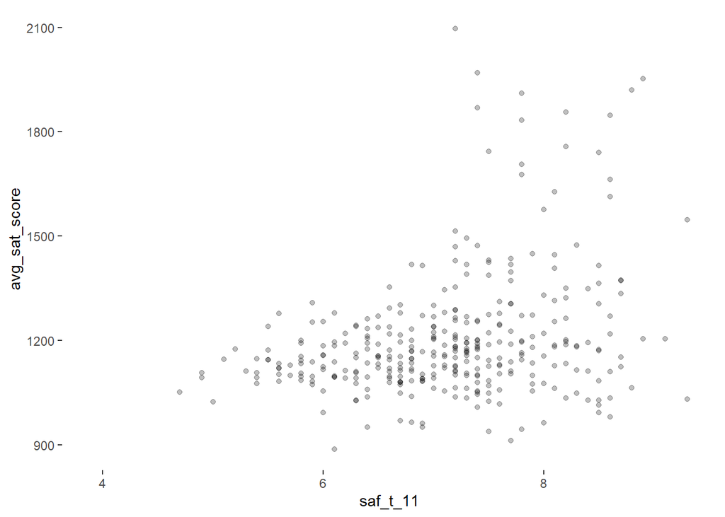

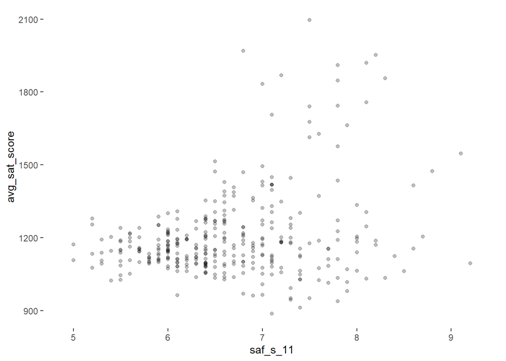

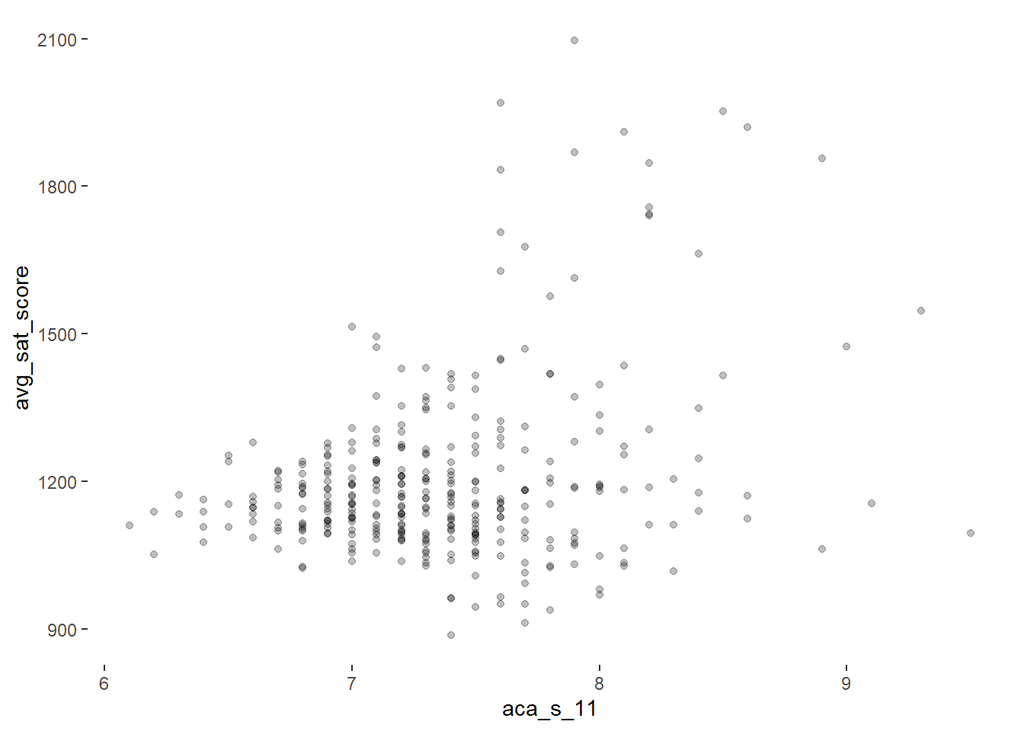

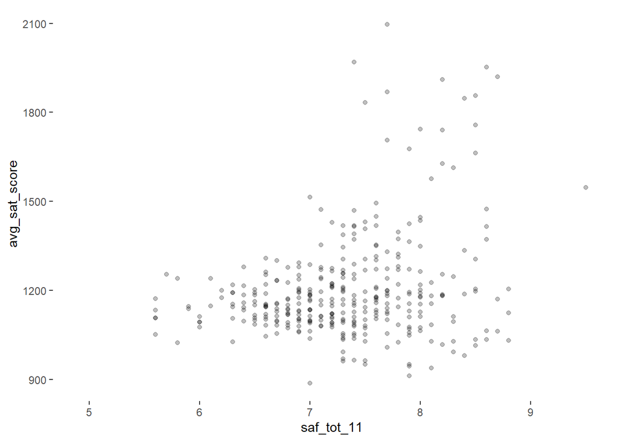

```r
# Filtering the columns which has absolute corr higher than 0.25
high_corr <- cor_mat %>% select(variable, avg_sat_score) %>% filter((abs(avg_sat_score) > 0.25) & (variable != 'avg_sat_score'))

# Getting the  names
cols <- high_corr$variable[1:4]

# Plotting scatter plots for the columns
for (i in cols){
  temp <- ggplot(data = combined_survey, aes(x = combined_survey[[i]], y = avg_sat_score)) + geom_point(alpha = 0.25) + labs(x= toString(i)) + theme(panel.background = element_rect(fill = "white"))
print(temp)
}
```

It was not quite clear, but we could interpret all of the graphs above to have a positive correlation to `avg_sat_score` just like the correlation matrix. We could also guess that the strength of the correlation is not that strong

### 2. Difference of Response

We knew that there are four respondents for the survey, which are:

1. Students
2. Teachers
3. Parents
4. Total

We will now investigate whether there are differences in how they respond to the questions for each metrics. To do this, we will need to reshape the data and add some new columns.

```r
# Using pivot longer for the surveys
combined_survey_gather <- combined_survey %>%
  pivot_longer(cols = saf_p_11:aca_tot_11,
               names_to = "survey_question",
               values_to = "score")

# Extracting the metrics and the respondent
combined_survey_gather <- combined_survey_gather %>%
  mutate(respondent = str_sub(survey_question, 4, 6)) %>%
  mutate(question = str_sub(survey_question, 1, 3))

# Converting respondent into interpret-able form
combined_survey_gather <- combined_survey_gather %>%
  mutate(respondent = ifelse(respondent  == "_p_", "parent",
                                ifelse(respondent == "_t_", "teacher",
                                       ifelse(respondent == "_s_", "student",
                                              ifelse(respondent == "_to", "total", "NA")
                                              )
                                       )
                           )
         )
```

After that, we utilize boxplots to visualize whether there are indeed differences in the answers from the respondents.

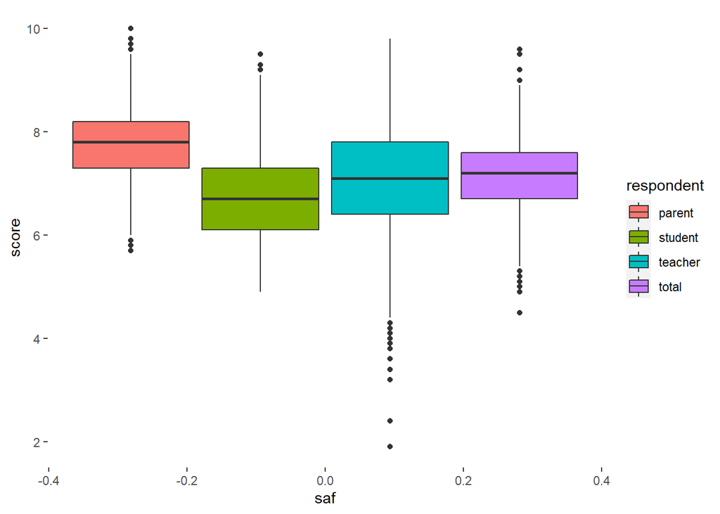

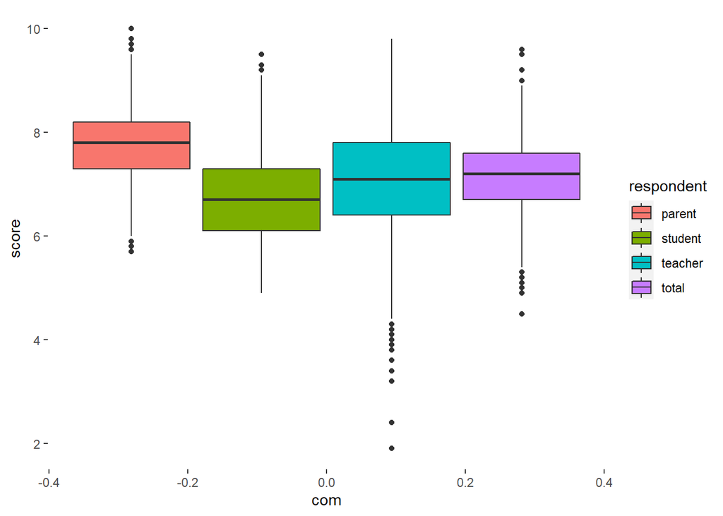

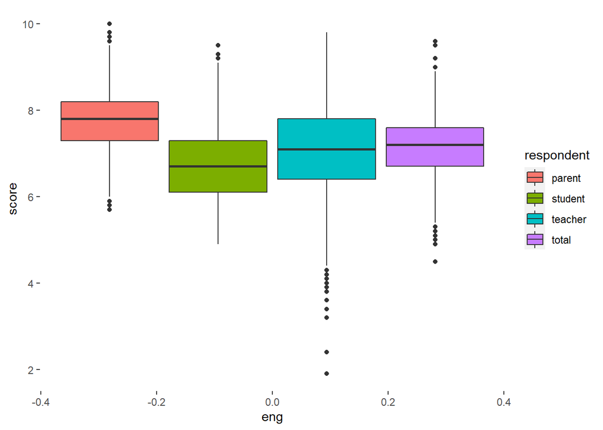

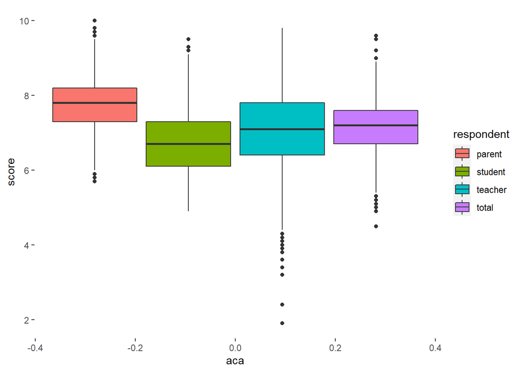

```r
# Plotting boxplots
for (i in unique(combined_survey_gather$question)){
  temp <- combined_survey_gather %>% ggplot(aes(x = combined_survey_gather[[i]], y = score ,fill = respondent)) + geom_boxplot() + labs(x= toString(i)) + theme(panel.background = element_rect(fill = "white"))
  print(temp)
}
```

## Conclusion

To conclude this exercise, there were two things that needs to be noted:

1. Safety seems to be the most important factor in terms of academic success
2. Teachers and parents seem to have better opinion of all the metrics compared to students